[Link to GitHub Repository](https://momotheduckyy.github.io/)

# Exploring the Realtionship between Spotify Stream Count Over Time and a Song's Attributes: By Mohini Yadav and Erin Nell

# Project Overview

**Datsets**

We will be conducting an analysis on the following two datasets:

[Spotify Songs Streamed 2023 Dataset:](https://www.kaggle.com/datasets/abdulszz/spotify-most-streamed-songs?resource=download)

This dataset reports the songs with the most streams of the Spotify streaming platform as of 2023. Aside from stream count on Spotify, it includes the song title, artist, and additional details like the attributes of the song. For example, the song's danceability, speechiness, and valence. This attributes are measured on a scale from 0.0-1.0. We later convert this to a percentage scale from 0-100%. Each attribute is calculated by analyzing different aspects of the song. Throughout our analysis we will come to analyze the following attributes:

1. **Danceability:** Measures how likely someone is to dance to a song. This is based off of various elements, such as tempo, rhythm stability, beat strength, and overall regularity. It is measured on a scale of 0.0 is least danceable and 1.0 is most danceable.
2. **Speechiness:** Detects the amount of spoken words in a song. A track on spotify with a measure of 1.0 is only spoken word, most likely an audio book. Values between 0.33 and 0.66 include both music and spoken word, such as rap songs. And tracks belwo 0.33 are most likely types of music without spoken words.
3. **Valence:** Measures the songs positivity. Tracks closer to 1.0. sound more positive, such as happy or cheerful. Tracks closer to 0.0 sound negative, such as sad, depressed, or angry. In general, Spotify measures this using a set of agreed upon notions of what happy or positive music sounds like.

For further reading on how other attributes are measured in the dataset, see [Spotify's list of audio features](https://developer.spotify.com/documentation/web-api/reference/get-audio-features). This dataset also includes intrastic statiststics on a song's performance on other streaming platforms, such as Apple Music or Deezer.

[Spotify Songs Streamed 2024 Dataset:](https://www.kaggle.com/datasets/nelgiriyewithana/most-streamed-spotify-songs-2024/data)

This dataset reports the songs with the most streams on Spotify in 2024. Note that this is cumulative and is the songs stream count from its release to 2024, not just for the year of 2024. Like the dataset for 2023, it includes a track title, the artist, and the stream count on Spotify. In addition, it includes a song's performance on social media platforms like TikTok and YouTube. This dataset does not include data on a track's attributes but does include whether or not the track is explicit.

Note, both of these datasets were obtained from Kaggle and made by the same author.

**Motivation**

We believe that working with Spotify streaming data presents a unique opportunity to further understand market insights and song performance. Analyzing streaming data helps us understand current music trends, and evolving listener preferences. This insight can be valuable for artists, producers, and marketers in the music industry. For example, the ability to predict which songs are likely to gain more streams could influence how artists, labels, and platforms market songs, curate playlists, and tailor recommendations. With song performance, understanding which songs perform best on streaming platforms can inform marketing strategies and decisions on which songs to promote.

Our analysis also highlights how data science can be used to uncover insights and trends in music behavior. Moreover, how data science methods can be applied beyond traditional fields, showing their broad applicability to music data

Through data science techniques, this notebook will explore relationships between the attributes of songs, such as liveliness, danceability, and valence, and and the growth of a songs stream count over time. We use linear regression modeling to understand whether the relationship between the two, and the accuracy of whether a song's stream count can be predicted with one attribute versus having all the attribute. Furthermore, this notebooks includes further analysis of our datasets, showing correlation and identifying songs with the largest growth in stream count. This analysis can be used as the foundation for further analysis into what effects a song's continued growth on streaming platforms such as Spotify.

**Research Questions**

Throughout the analysis, our guiding research questions were:

1. Can we use the Spotify stream count to understand why some songs remain the most streamed?
2. Specifically, do attributes such as valence, speechiness, or danceability relate to a song's stream count over time?
3. Can we use these attributes to predict a songs growth in streams from 2023-24?

**Collaboration Plan**

The team plans to meet once a week to work on and discuss the project and determine next steps. We will also communicate frequently over text messages to stay updated with our progress on the project and, if necessary, we will meet over facetime or schedule additional in-person meetings. We also have a Google Doc which has a list of to-do items and general notes about the project. Lastly, we have a shared Github repository where we may store and update our code.

# Extraction, Transform, and Load

We begin our analysis by loading our datasets into DataFrames and transforming them into a more usable format:

```python
from google.colab import drive
drive.mount('/content/drive')
```

```python
import pandas as pd
import numpy as np
import matplotlib.pyplot as plt
import warnings
import seaborn as sns
warnings.filterwarnings("ignore", category=pd.errors.SettingWithCopyWarning)
```

We will first load our Spotify streaming data for 2023. We tidy the data by removing unwanted columns, such as the the cover_url link which we would not be using in our analysis, ensuring the data is the correct type, and replacing cells incomplete data with NaN values or deleting the row depending on the context.

```python
path = '/content/drive/My Drive/spotify/spotifymoststreamed.csv'
df = pd.read_csv(path)
df.head()
```

|  | track_name | artist(s)_name | artist_count | released_year | released_month | released_day | in_spotify_playlists | in_spotify_charts | streams | in_apple_playlists | ... | key | mode | danceability_% | valence_% | energy_% | acousticness_% | instrumentalness_% | liveness_% | speechiness_% | cover_url |
| --- | --- | --- | --- | --- | --- | --- | --- | --- | --- | --- | --- | --- | --- | --- | --- | --- | --- | --- | --- | --- | --- |
| 0 | Seven (feat. Latto) (Explicit Ver.) | Latto, Jung Kook | 2 | 2023 | 7 | 14 | 553 | 147 | 141381703 | 43 | ... | B | Major | 80 | 89 | 83 | 31 | 0 | 8 | 4 | Not Found |
| 1 | LALA | Myke Towers | 1 | 2023 | 3 | 23 | 1474 | 48 | 133716286 | 48 | ... | C# | Major | 71 | 61 | 74 | 7 | 0 | 10 | 4 | https://i.scdn.co/image/ab67616d0000b2730656d5... |
| 2 | vampire | Olivia Rodrigo | 1 | 2023 | 6 | 30 | 1397 | 113 | 140003974 | 94 | ... | F | Major | 51 | 32 | 53 | 17 | 0 | 31 | 6 | https://i.scdn.co/image/ab67616d0000b273e85259... |
| 3 | Cruel Summer | Taylor Swift | 1 | 2019 | 8 | 23 | 7858 | 100 | 800840817 | 116 | ... | A | Major | 55 | 58 | 72 | 11 | 0 | 11 | 15 | https://i.scdn.co/image/ab67616d0000b273e787cf... |
| 4 | WHERE SHE GOES | Bad Bunny | 1 | 2023 | 5 | 18 | 3133 | 50 | 303236322 | 84 | ... | A | Minor | 65 | 23 | 80 | 14 | 63 | 11 | 6 | https://i.scdn.co/image/ab67616d0000b273ab5c9c... |

5 rows × 25 columns

First, we are removing columns not valuable to our analysis. We are removing any column which refers to the number of playlists since we do not have the scale. i.e. how many playlists on the platform, so we can not compare this number across platforms.

```python
# drop cover_url since it is not useful to our analysis
df = df.drop(['cover_url', 'in_spotify_playlists', 'in_apple_playlists', 'in_deezer_playlists', 'in_apple_charts', 'in_deezer_charts', 'in_shazam_charts', 'released_month', 'released_day', 'mode', 'in_spotify_charts', 'key'], axis=1)
```

Ensure that the data has correct types. We want to make sure that each data type correctly reflects the type of value in that variable. Also, looking at this initial code, there are lots of values with missing data, so we are replacing empty cells with NaN. We will not be removing the columns entirely because the row still provides important data about streaming count which could be analyzed seperately.

```python
# Identify rows with non-numeric 'streams' values
non_numeric_streams = df[~df['streams'].str.isnumeric()]

# remove row
df = df.drop(574)

# replace missing values with NaNs
df = df.replace({'': np.nan, None: np.nan})

# fixing data types by converting from int64 to object since we want to view dates as categorical variables
df['released_year'] = df['released_year'].astype('object')
#df['released_month'] = df['released_month'].astype('object')
#df['released_day'] = df['released_day'].astype('object')

# convert "streams" to an integer (currently prints as object)
df['streams'] = df['streams'].astype('int64')

df.dtypes
```

|  | 0 |
| --- | --- |
| track_name | object |
| artist(s)_name | object |
| artist_count | int64 |
| released_year | object |
| streams | int64 |
| bpm | int64 |
| danceability_% | int64 |
| valence_% | int64 |
| energy_% | int64 |
| acousticness_% | int64 |
| instrumentalness_% | int64 |
| liveness_% | int64 |
| speechiness_% | int64 |

**dtype:** object

```python
df.head()
```

|  | track_name | artist(s)_name | artist_count | released_year | streams | bpm | danceability_% | valence_% | energy_% | acousticness_% | instrumentalness_% | liveness_% | speechiness_% |
| --- | --- | --- | --- | --- | --- | --- | --- | --- | --- | --- | --- | --- | --- |
| 0 | Seven (feat. Latto) (Explicit Ver.) | Latto, Jung Kook | 2 | 2023 | 141381703 | 125 | 80 | 89 | 83 | 31 | 0 | 8 | 4 |
| 1 | LALA | Myke Towers | 1 | 2023 | 133716286 | 92 | 71 | 61 | 74 | 7 | 0 | 10 | 4 |
| 2 | vampire | Olivia Rodrigo | 1 | 2023 | 140003974 | 138 | 51 | 32 | 53 | 17 | 0 | 31 | 6 |
| 3 | Cruel Summer | Taylor Swift | 1 | 2019 | 800840817 | 170 | 55 | 58 | 72 | 11 | 0 | 11 | 15 |
| 4 | WHERE SHE GOES | Bad Bunny | 1 | 2023 | 303236322 | 144 | 65 | 23 | 80 | 14 | 63 | 11 | 6 |

**Joining an Additional Dataset for Spotify Streams 2024**

Now, we are adding a second dataset which looks at the songs with the most streams in 2024 on spotify. We are going to analyze this dataset, which offers additional insights such as whether a song is explicit and its stream count for songs on Spotify for 2024.

With our joined data, we want to find out if there any songs that have remained popular over between 2023 and 2024 and what characteristics these songs have.

```python
# uploading our new dataset
path3 = '/content/drive/My Drive/spotify/moststreamedspotify2024.csv'
df2024 = pd.read_csv(path3, encoding='ISO-8859-1')
df2024.head()
```

|  | Track | Album Name | Artist | Release Date | ISRC | All Time Rank | Track Score | Spotify Streams | Spotify Playlist Count | Spotify Playlist Reach | ... | SiriusXM Spins | Deezer Playlist Count | Deezer Playlist Reach | Amazon Playlist Count | Pandora Streams | Pandora Track Stations | Soundcloud Streams | Shazam Counts | TIDAL Popularity | Explicit Track |
| --- | --- | --- | --- | --- | --- | --- | --- | --- | --- | --- | --- | --- | --- | --- | --- | --- | --- | --- | --- | --- | --- |
| 0 | MILLION DOLLAR BABY | Million Dollar Baby - Single | Tommy Richman | 4/26/2024 | QM24S2402528 | 1 | 725.4 | 390,470,936 | 30,716 | 196,631,588 | ... | 684 | 62.0 | 17,598,718 | 114.0 | 18,004,655 | 22,931 | 4,818,457 | 2,669,262 | NaN | 0 |
| 1 | Not Like Us | Not Like Us | Kendrick Lamar | 5/4/2024 | USUG12400910 | 2 | 545.9 | 323,703,884 | 28,113 | 174,597,137 | ... | 3 | 67.0 | 10,422,430 | 111.0 | 7,780,028 | 28,444 | 6,623,075 | 1,118,279 | NaN | 1 |
| 2 | i like the way you kiss me | I like the way you kiss me | Artemas | 3/19/2024 | QZJ842400387 | 3 | 538.4 | 601,309,283 | 54,331 | 211,607,669 | ... | 536 | 136.0 | 36,321,847 | 172.0 | 5,022,621 | 5,639 | 7,208,651 | 5,285,340 | NaN | 0 |
| 3 | Flowers | Flowers - Single | Miley Cyrus | 1/12/2023 | USSM12209777 | 4 | 444.9 | 2,031,280,633 | 269,802 | 136,569,078 | ... | 2,182 | 264.0 | 24,684,248 | 210.0 | 190,260,277 | 203,384 | NaN | 11,822,942 | NaN | 0 |
| 4 | Houdini | Houdini | Eminem | 5/31/2024 | USUG12403398 | 5 | 423.3 | 107,034,922 | 7,223 | 151,469,874 | ... | 1 | 82.0 | 17,660,624 | 105.0 | 4,493,884 | 7,006 | 207,179 | 457,017 | NaN | 1 |

5 rows × 29 columns

First, we want to cleanup this dataset. There are a few things we wish to do, such as replacing null values with NaN, although at a glance it looks like there are none. We will also drop columns we will not use and remove commas in the number values so that it matches with the 2023 dataset.

```python
df_tidy2024 = df2024

# replacing empty entries, if any, with NaN
df_tidy2024 = df_tidy2024.replace({'': np.nan, None: np.nan})

# dropping columns not useful to our analysis
df_tidy2024 = df_tidy2024.drop(['Spotify Playlist Count', 'Spotify Playlist Reach', 'SiriusXM Spins',
                                'Deezer Playlist Reach', 'Amazon Playlist Count', 'Pandora Streams',
                                'Pandora Track Stations', 'Soundcloud Streams', 'Shazam Counts', 'TIDAL Popularity',
                                 'Apple Music Playlist Count', 'Deezer Playlist Count',
                                'Apple Music Playlist Count', 'YouTube Playlist Reach', 'ISRC', 'AirPlay Spins',
                                'TikTok Views', 'YouTube Views', 'TikTok Posts', 'TikTok Likes', 'YouTube Likes'], axis=1)

# remove commas in the numbers to match our first dataset
df_tidy2024['Spotify Streams'] = df_tidy2024['Spotify Streams'].str.replace(',', '', regex = False)

df_tidy2024.head()
```

|  | Track | Album Name | Artist | Release Date | All Time Rank | Track Score | Spotify Streams | Spotify Popularity | Explicit Track |
| --- | --- | --- | --- | --- | --- | --- | --- | --- | --- |
| 0 | MILLION DOLLAR BABY | Million Dollar Baby - Single | Tommy Richman | 4/26/2024 | 1 | 725.4 | 390470936 | 92.0 | 0 |
| 1 | Not Like Us | Not Like Us | Kendrick Lamar | 5/4/2024 | 2 | 545.9 | 323703884 | 92.0 | 1 |
| 2 | i like the way you kiss me | I like the way you kiss me | Artemas | 3/19/2024 | 3 | 538.4 | 601309283 | 92.0 | 0 |
| 3 | Flowers | Flowers - Single | Miley Cyrus | 1/12/2023 | 4 | 444.9 | 2031280633 | 85.0 | 0 |
| 4 | Houdini | Houdini | Eminem | 5/31/2024 | 5 | 423.3 | 107034922 | 88.0 | 1 |

Next, we want to ensure that the data is of the correct type, categorical or numerical, for when we start analyzing it:

```python
# fixing data types by converting from int64 to object since we want to view dates as categorical variables
  # drop any data that doesnt have a number for spotify streams since thats what we are focusing on
df_tidy2024 = df_tidy2024.dropna(subset=['Spotify Streams'])
df_tidy2024['Spotify Streams'] = df_tidy2024['Spotify Streams'].astype('int64')

# fix the type for the explicit track column to boolean
df_tidy2024['Explicit Track'] = df_tidy2024['Explicit Track'].replace({0: False, 1: True}).astype(bool)

df_tidy2024.dtypes
```

|  | 0 |
| --- | --- |
| Track | object |
| Album Name | object |
| Artist | object |
| Release Date | object |
| All Time Rank | object |
| Track Score | float64 |
| Spotify Streams | int64 |
| Spotify Popularity | float64 |
| Explicit Track | bool |

**dtype:** object

We are going to join the datsets by the song and artist and tidy the data so we can draw conclusions during our analysis. Note, that we are creating a new column, 'stream_change', which is found by subtracting 'streams_2024' and 'streams_2023' to find the total streaming count growth for a song that appears on both datasets. This will effectively allow us to see which songs performed the best over time for 2023-24.

```python
df2023 = df
df2024 = df_tidy2024

# standardizing the column names for when we merge
df2023.rename(columns={'track_name': 'song', 'artist(s)_name': 'artist'}, inplace=True)
df2024.rename(columns={'Track': 'song', 'Artist': 'artist'}, inplace=True)

# merging the the dataframes based on an inner join so we only get songs that appear both in 2023 and 2024
merged_dfs = pd.merge(df2023, df2024, on=['song', 'artist'], how='inner')

# dropping columns we dont need
merged_dfs = merged_dfs.drop(columns=['Release Date', 'Album Name', 'All Time Rank', 'Spotify Popularity', 'Track Score'])

# renaming based on year
merged_dfs.rename(columns={'streams': 'streams_2023', 'Spotify Streams': 'streams_2024'}, inplace=True)

# add new column which shows the difference between the stream count by year
merged_dfs['stream_change'] = merged_dfs['streams_2024'] - merged_dfs['streams_2023']

# remove songs with a negative stream change since that is impossible and means the stream count was entered in incorrectly
merged_dfs = merged_dfs[merged_dfs['stream_change'] >= 0]

# creating a new column order so (spotify) streams are next to each other
new_column_order = ['song', 'artist', 'artist_count', 'released_year', 'streams_2023', 'streams_2024', 'stream_change',
                    'bpm', 'danceability_%', 'valence_%', 'energy_%', 'acousticness_%', 'instrumentalness_%',
                    'liveness_%', 'speechiness_%', 'Explicit Track']
merged_dfs = merged_dfs[new_column_order]

# if there are duplicates, so keep first occurence of the duplicate
merged_dfs = merged_dfs[~merged_dfs['song'].duplicated(keep='first')]

merged_dfs.head()
```

|  | song | artist | artist_count | released_year | streams_2023 | streams_2024 | stream_change | bpm | danceability_% | valence_% | energy_% | acousticness_% | instrumentalness_% | liveness_% | speechiness_% | Explicit Track |
| --- | --- | --- | --- | --- | --- | --- | --- | --- | --- | --- | --- | --- | --- | --- | --- | --- |
| 0 | LALA | Myke Towers | 1 | 2023 | 133716286 | 925655569 | 791939283 | 92 | 71 | 61 | 74 | 7 | 0 | 10 | 4 | True |
| 1 | vampire | Olivia Rodrigo | 1 | 2023 | 140003974 | 998964097 | 858960123 | 138 | 51 | 32 | 53 | 17 | 0 | 31 | 6 | True |
| 3 | Cruel Summer | Taylor Swift | 1 | 2019 | 800840817 | 2188247133 | 1387406316 | 170 | 55 | 58 | 72 | 11 | 0 | 11 | 15 | False |
| 4 | WHERE SHE GOES | Bad Bunny | 1 | 2023 | 303236322 | 717849037 | 414612715 | 144 | 65 | 23 | 80 | 14 | 63 | 11 | 6 | True |
| 6 | Columbia | Quevedo | 1 | 2023 | 58149378 | 721002940 | 662853562 | 100 | 67 | 26 | 71 | 37 | 0 | 11 | 4 | False |

Making sure that the data has the correct types again:

```python
# tidy data to be in the correct type for when we conduct an analysis
merged_dfs['released_year'] = merged_dfs['released_year'].astype('object')
merged_dfs.dtypes
```

|  | 0 |
| --- | --- |
| song | object |
| artist | object |
| artist_count | int64 |
| released_year | object |
| streams_2023 | int64 |
| streams_2024 | int64 |
| stream_change | int64 |
| bpm | int64 |
| danceability_% | int64 |
| valence_% | int64 |
| energy_% | int64 |
| acousticness_% | int64 |
| instrumentalness_% | int64 |
| liveness_% | int64 |
| speechiness_% | int64 |
| Explicit Track | bool |

**dtype:** object

# Exploratory Data Analysis

**Summary Statistics and Understanding the Data**

We will first start by finding the summary statistics for our joined dataset to get an overall sense of what our data is telling us. We can see that on average, songs have a stream change of 236,216,100 with a standard deviation of 179,683,500. It is important to acknowledge that the standard deviation is large, hinting that their is a wide variety of values for stream_change. This is evident by the minimum and and maximum, being 12,307,680 and 1,387,406,000 respectively.

```python
# Summary Statistics for our merged dataset
merged_dfs.describe()
```

|  | artist_count | streams_2023 | streams_2024 | stream_change | bpm | danceability_% | valence_% | energy_% | acousticness_% | instrumentalness_% | liveness_% | speechiness_% |
| --- | --- | --- | --- | --- | --- | --- | --- | --- | --- | --- | --- | --- |
| count | 379.000000 | 3.790000e+02 | 3.790000e+02 | 3.790000e+02 | 379.000000 | 379.000000 | 379.000000 | 379.000000 | 379.000000 | 379.000000 | 379.000000 | 379.000000 |
| mean | 1.007916 | 6.485909e+08 | 8.848070e+08 | 2.362161e+08 | 124.683377 | 65.620053 | 50.092348 | 63.042216 | 26.939314 | 1.981530 | 17.493404 | 9.203166 |
| std | 0.088734 | 6.273042e+08 | 7.290242e+08 | 1.796835e+08 | 29.335498 | 14.573050 | 23.499058 | 16.649779 | 26.351190 | 9.893196 | 12.784201 | 8.869029 |
| min | 1.000000 | 1.478042e+07 | 8.980664e+07 | 1.230768e+07 | 65.000000 | 25.000000 | 4.000000 | 9.000000 | 0.000000 | 0.000000 | 3.000000 | 2.000000 |
| 25% | 1.000000 | 2.029495e+08 | 3.428159e+08 | 1.019014e+08 | 100.000000 | 56.000000 | 31.000000 | 52.000000 | 5.000000 | 0.000000 | 10.000000 | 4.000000 |
| 50% | 1.000000 | 3.875707e+08 | 5.995475e+08 | 1.912990e+08 | 123.000000 | 67.000000 | 49.000000 | 63.000000 | 16.000000 | 0.000000 | 12.000000 | 6.000000 |
| 75% | 1.000000 | 9.145238e+08 | 1.250718e+09 | 3.262491e+08 | 143.500000 | 76.500000 | 68.000000 | 77.000000 | 43.000000 | 0.000000 | 22.000000 | 10.000000 |
| max | 2.000000 | 3.703895e+09 | 4.281469e+09 | 1.387406e+09 | 206.000000 | 95.000000 | 97.000000 | 97.000000 | 97.000000 | 90.000000 | 83.000000 | 46.000000 |

Next, we wanted to look into some of the additional attributes included in this dataset, such as the average percentage of a song's danceability, valence, and speechiness. Moreover, we look at the standard deviation to see how much they vary. For instance, we see that valence has a relatively large variation in data points (std = 23.50, rounded) than the other attributes. Speechiness has the smallest standard deviation, hinting that many of the values are near the mean. This is evident by the third quartile (75%), where it says that 75% of the data falls below 10% speechiness. Danceability has a larger standard deviation (14.57).

```python
# combine acousticness_% with energy_%
combined_dfs = pd.concat([merged_dfs['danceability_%'], merged_dfs['valence_%'], merged_dfs['speechiness_%']], axis=1)

# descriptive statistics for both variables
described = combined_dfs.describe()
described
```

|  | danceability_% | valence_% | speechiness_% |
| --- | --- | --- | --- |
| count | 379.000000 | 379.000000 | 379.000000 |
| mean | 65.620053 | 50.092348 | 9.203166 |
| std | 14.573050 | 23.499058 | 8.869029 |
| min | 25.000000 | 4.000000 | 2.000000 |
| 25% | 56.000000 | 31.000000 | 4.000000 |
| 50% | 67.000000 | 49.000000 | 6.000000 |
| 75% | 76.500000 | 68.000000 | 10.000000 |
| max | 95.000000 | 97.000000 | 46.000000 |

It will also be helpful to see what song was the most streamed in 2023, 2024, and which song has had the most growth from 2023-24. Let's check to see if they are all the same song.

```python
# most streamed song in 2023
most_streamed_2023 = merged_dfs.loc[merged_dfs['streams_2023'].idxmax()]

# most streamed song in 2024
most_streamed_2024 = merged_dfs.loc[merged_dfs['streams_2024'].idxmax()]

# find the song with the highest number for stream_change
top_change = merged_dfs.loc[merged_dfs['stream_change'].idxmax()]

print("Most Streamed Song in 2023:")
print(most_streamed_2023[['song', 'streams_2023']])

print("\nMost Streamed Song in 2024:")
print(most_streamed_2024[['song', 'streams_2024']])

print("\nSong with Greatest Stream Change:")
print(top_change[['song', 'stream_change']])
```

```
Most Streamed Song in 2023:
song            Blinding Lights
streams_2023         3703895074
Name: 33, dtype: object

Most Streamed Song in 2024:
song            Blinding Lights
streams_2024         4281468720
Name: 33, dtype: object

Song with Greatest Stream Change:
song             Cruel Summer
stream_change      1387406316
Name: 3, dtype: object
```

Interestingly, this just so happens to be the same song for both 2023 and 2024 top songs, Blinding Lights by The Weeknd. We can conclude that no song has been able to outshine Blinding Lights. However, notice that although very popular, this song has not had the most growth for 2023-2024. That title goes to Cruel Summer by Taylor swift. Lets look at the stream change for Blinding Lights. We can see that there was a growth of 577,573,646 streams between 2023 and 2024. Although a large number, looking at our bar chart analysis below, we can conclude that although incredibly popular, The Weeknd's Blinding Lights does not have the same growth as some of the other songs during these years. Further investigation can be done later on to understand what makes a strong have a high stream count versus a sustained high stream count. Hence, we are going to consider the column, stream_change (streams_2024 minus streams_2023) to the growth of a songs streams over time.

```python
# find the stream change value for the song "Blinding Lights"
merged_dfs[merged_dfs['song'].str.lower() == 'blinding lights']['stream_change']
```

|  | stream_change |
| --- | --- |
| 33 | 577573646 |

**dtype:** int64

Also, as mentioned, we see that Taylor Swift's Cruel Summer had the greatest stream change in 2023-24 but is not the most streamed song (we see later on that it is also not in the top 10 list for 2023 or 2024) but it was released in 2019, as shown below. Although we will analyze its attributes later, this could be an initial hint of outside factors affecting a song's performance. For instance, Taylor Swift has gone on tour and the song has gotten popular on TikTok, likely being some of the factors for its sudden growth. We can therefore infer that although attributes like acousticness, valence, and danceability may affect how much a song is streamed, which we explore with further analysis, there are many other influencing factors.

```python
# print row with the song cruel summer
cruel_summer = merged_dfs[merged_dfs['song'] == 'Cruel Summer']
cruel_summer
```

|  | song | artist | artist_count | released_year | streams_2023 | streams_2024 | stream_change | bpm | danceability_% | valence_% | energy_% | acousticness_% | instrumentalness_% | liveness_% | speechiness_% | Explicit Track |
| --- | --- | --- | --- | --- | --- | --- | --- | --- | --- | --- | --- | --- | --- | --- | --- | --- |
| 3 | Cruel Summer | Taylor Swift | 1 | 2019 | 800840817 | 2188247133 | 1387406316 | 170 | 55 | 58 | 72 | 11 | 0 | 11 | 15 | False |

**Top Songs on Spotify and Growth**

Another useful analysis we can make is finding a bar chart which looks at the songs which continued to grow in streams from 2023 and 2024. From this graph, we can help identify the songs that had a sustained popularity which we can later perform further analysis on to discover why these songs remained popular. Moreover, we can compare this to the top 10 songs with the largest increase in streams and perform further analysis to figure out what about these songs made them only perform well for a short period of time. First, we visualize the top 10 songs on the platform for 2023 and 2024. Not only is it interesting to see what songs have performed well, but the song As It Was by Harry Styles notably appears on the charts for top songs in 2023, 2024, and the songs with the largest growth (stream_change) for 2023-24.

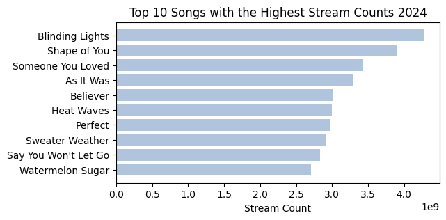

```python
# find the top 10 songs with the largest 2024 values
top_2024 = merged_dfs.nlargest(10, 'streams_2024')

# plot bar graph
plt.figure(figsize=(6, 3))
plt.barh(top_2024['song'], top_2024['streams_2024'], color='lightsteelblue')
plt.xlabel('Stream Count')
plt.title('Top 10 Songs with the Highest Stream Counts 2024')
plt.gca().invert_yaxis()
plt.show()
```

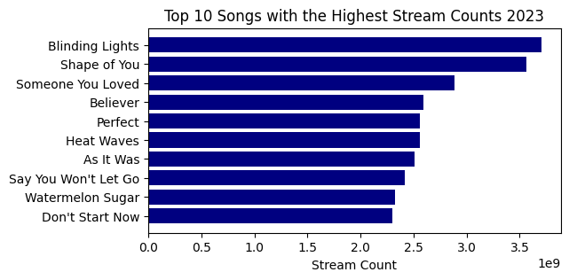

```python
# find the top 10 songs with the largest 2023 values
top_2023 = merged_dfs.nlargest(10, 'streams_2023')

# plot bar graph
plt.figure(figsize=(6, 3))
plt.barh(top_2023['song'], top_2023['streams_2023'], color='navy')
plt.xlabel('Stream Count')
plt.title('Top 10 Songs with the Highest Stream Counts 2023')
plt.gca().invert_yaxis()
plt.show()
```

Cruel Summer by Taylor Swift has the highest increase in streams by far. We can use use this information to understand what makes a song so popular.

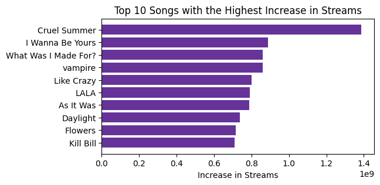

```python
# update the "song" column where the value matches "what I was I made"
  # this step is to make the format of the graph nice so song title does not appear too long
merged_dfs.loc[merged_dfs['song'] == 'What Was I Made For? [From The Motion Picture "Barbie"]', 'song'] = 'What Was I Made For?'

# find the top 10 songs with the largest stream_change values
top_change = merged_dfs.nlargest(10, 'stream_change')

# plot bar graph
plt.figure(figsize=(6, 3))
plt.barh(top_change['song'], top_change['stream_change'], color='rebeccapurple')
plt.xlabel('Increase in Streams')
plt.title('Top 10 Songs with the Highest Increase in Streams')
plt.gca().invert_yaxis()
plt.show()
```

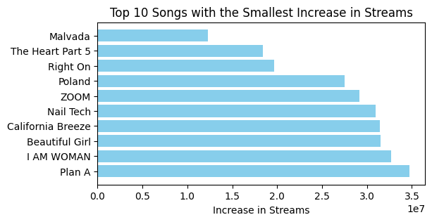

```python
# find the top 10 songs with the smallest stream_change values
top_losers = merged_dfs.nsmallest(10, 'stream_change')

# plot bar graph
plt.figure(figsize=(6, 3))
plt.barh(top_losers['song'], top_losers['stream_change'], color='skyblue')
plt.xlabel('Increase in Streams')
plt.title('Top 10 Songs with the Smallest Increase in Streams')
plt.gca().invert_yaxis()
plt.show()
```

We thus observe that being one of the top songs on the platform does not necessarily mean that the song had the most growth for 2023-24. We visualize this difference with a bar chart.

[figure not shown]

```python
# list of songs to include in the bar graph
selected_songs = ['Blinding Lights', 'Shape of You', 'Someone You Loved', 'Believer', 'Perfect',
                  'Heat Waves', 'As It Was', "Say you Won't Let Go", 'Watermelon Sugar', "Don't Start Now", 'Cruel Summer',
                  'I Wanna Be Yours', 'What Was I Made For', 'vampire', 'Like Crazy', 'LALA', 'As It Was', 'Daylight', 'Flowers', 'Kill Bill']

highlighted_songs = ['Cruel Summer', 'I Wanna Be Yours', 'What Was I Made For', 'vampire', 'Like Crazy', 'LALA',
                     'Daylight', 'Flowers', 'Kill Bill', 'As It Was']

# filter the dataset for the selected songs
filtered_df = merged_dfs[merged_dfs['song'].isin(selected_songs)]

# assign colors based on whether the song is in the highlighted list
colors = ['thistle' if song not in highlighted_songs else 'steelblue' for song in filtered_df['song']]

# plot the bar graph
plt.figure(figsize=(9, 5))
plt.bar(filtered_df['song'], filtered_df['stream_change'], color=colors)

# add labels and title
plt.title('Top 10 Songs with Highest Stream Change vs  Songs with Highest 2024 Stream Count')
plt.xlabel('Song Title')
plt.ylabel('Stream Change')
plt.xticks(rotation=45, ha='right')
plt.show()
```

**Correlations Between Attributes and Stream Growth**

A heatmap is going to be a good way to quickly gauge the correlation between different variables. We see that variables like speechiness, valence, and danceability have negative correlations to stream_change and that is weak, but still substantial. This information will provide the foundation for our models, in that we believe that there is some correlation between these attributes (our independent variables) and stream change (the dependent variable). Also, interestingly, there is a moderate correlation between danceability and valence. The relationship between the rest of the independent variables to each other (speechiness and valence, danceability and speechiness, etc.) show a relatively week correlation.

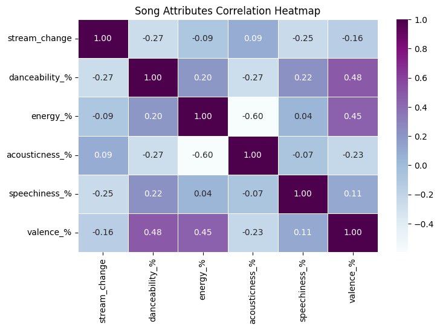

```python
# columns to include in heatmap
selected_columns = ['stream_change', 'danceability_%',
                    'energy_%', 'acousticness_%', 'speechiness_%', 'valence_%']

# remove rows with NaN values in 'speechiness_%' and 'danceability_%', valence_%
heat_filtered = merged_dfs.dropna(subset=['speechiness_%', 'danceability_%', 'valence_%'])

# filter merged_dfs to only include the selected columns
heat_filtered = merged_dfs[selected_columns]

# calculate the correlation matrix
correlation_matrix = heat_filtered.corr()

# plot heatmap
plt.figure(figsize=(8, 5))
sns.heatmap(correlation_matrix, annot=True, cmap='BuPu', fmt=".2f", linewidths=0.5)
plt.title('Song Attributes Correlation Heatmap')
plt.show()
```

**Visualizing Correlation via Scatter Plots:**

To get a better visualization of the correlation matrix above, we will plot the relationship between each attribute seperately and the stream change of a track. Below, we can see that none of the plots have a generally strong correlation, but they are all have a negative correlation. In other words, as the attribute percentage increases, the stream change decreases.

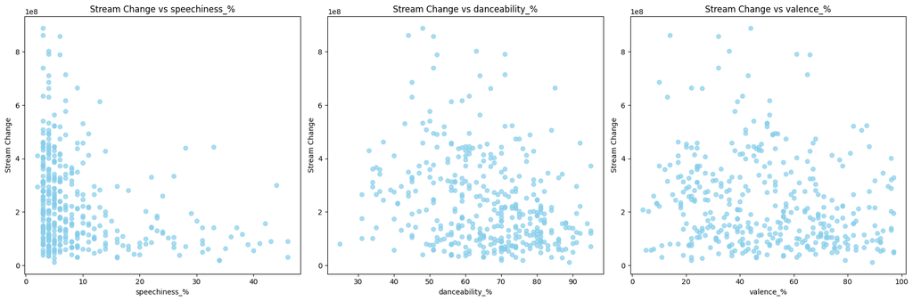

```python
# remove rows with NaN values in 'Speechiness_%' and 'danceability_%'
merged_dfs_heat = merged_dfs.dropna(subset=['speechiness_%', 'danceability_%', 'valence_%'])

# removing song Cruel Summer to better visualize the data because it is such a large outlier
merged_dfs_heat = merged_dfs_heat[merged_dfs_heat['song'] != 'Cruel Summer']

# features to compare with stream_change
features = ['speechiness_%', 'danceability_%', 'valence_%']

# create subplots
plt.figure(figsize=(18, 6))
for i, feature in enumerate(features, 1):
    plt.subplot(1, len(features), i)
    plt.scatter(merged_dfs_heat[feature], merged_dfs_heat['stream_change'], alpha=0.7, color='skyblue')
    # adding labels and titles
    plt.title(f'Stream Change vs {feature}')
    plt.xlabel(feature)
    plt.ylabel('Stream Change')

# adjusting layout to prevent overlap
plt.tight_layout()
plt.show()
```

**Comparing Average Speechiness, Danceability, and Valence for the Top 10 Songs Versus All Songs:**

Now that we see that there is a negative correlation between the variables, we want to get a better idea of how this is reflected in our data. Lets see the average speechiness, danceability, and valence in the data and what this posibily means and break down our analysis:

1. Speechiness_%: we see that for the all the songs from this dataset, the average speechiness is 9.2%. As this falls below 33% we can assume these songs are not of the rap genre. Furthermore, the top 10 songs have a lower average speechiness of 5.5%, meaning that there may be a correlation between fewer spoken words and better performance.
2. Danceability_%: The top 10 songs also have a lower average danceability than the average for all the songs on the playlist. However, does this mean that songs perform best with an average danceability of 57%, or is this average possible swayed by an outlier. Further analysis will be performed. Despite this, all songs and the top 10 songs have an average danceability of above 50%, this may hit that danceable songs perform better.
3. Valence_%: the average valence for the top 10 songs is lower than the average for all of the songs on the dataset. We can infer that perhaps a song does not to be super positive to perform well. We will perform further analysis to see if the average for the top 10 songs is swayed by outliers.

Overall, we can see that the averages for these attributes falls relatively closely to the averages for all the songs on the dataset. This suggests that these attributes might influence a song's performance, but further statistical analysis is needed to confirm their significance. For further analysis, we will perform models to test our hypothesis as our last steps.

```python
# find the top 10 songs, songs with the large stream change count
top_10_songs = merged_dfs.nlargest(10, 'stream_change')

# calculate the average speechiness, danceability, and valence for top 10
top_avg = {'Average Speechiness %': top_10_songs['speechiness_%'].mean(),
    'Average Danceability %': top_10_songs['danceability_%'].mean(),
    'Average Valence %': top_10_songs['valence_%'].mean()}

# calculate the average speechiness, danceability, and valence for all songs
all_avg = {'Average Speechiness %': merged_dfs['speechiness_%'].mean(),
    'Average Danceability %': merged_dfs['danceability_%'].mean(),
    'Average Valence %': merged_dfs['valence_%'].mean()}

# combine both average values into a single dataframe
table = pd.DataFrame({
    'Top 10 Songs': list(top_avg.values()),
    'All Songs': list(all_avg.values()),
    # finding the differences between the top 10 songs and all songs for comparison
    # index =... gives the row titles
    'Difference': [a - b for b, a in zip(top_avg.values(), all_avg.values())]}, index=top_avg.keys())

table
```

|  | Top 10 Songs | All Songs | Difference |
| --- | --- | --- | --- |
| Average Speechiness % | 5.5 | 9.203166 | 3.703166 |
| Average Danceability % | 57.0 | 65.620053 | 8.620053 |
| Average Valence % | 45.1 | 50.092348 | 4.992348 |

```python
# find the bottom 10 songs, songs with the large stream change count
bottom_10_songs = merged_dfs.nsmallest(10, 'stream_change')

# calculate the average speechiness, danceability, and valence for the top 10
bottom_avg = {'Average Speechiness %': bottom_10_songs['speechiness_%'].mean(),
    'Average Danceability %': bottom_10_songs['danceability_%'].mean(),
    'Average Valence %': bottom_10_songs['valence_%'].mean()}

# Calculate the average speechiness, danceability, and valence for all songs
all_avg = {'Average Speechiness %': merged_dfs['speechiness_%'].mean(),
    'Average Danceability %': merged_dfs['danceability_%'].mean(),
    'Average Valence %': merged_dfs['valence_%'].mean()}

# combine both average values into a single dataframe
table = pd.DataFrame({
    'Bottom 10 Songs': list(bottom_avg.values()),
    'All Songs': list(all_avg.values()),
    # finding the difference between the two for comparison
    'Difference': [b - a for b, a in zip(bottom_avg.values(), all_avg.values())]}, index=bottom_avg.keys())

table
```

|  | Bottom 10 Songs | All Songs | Difference |
| --- | --- | --- | --- |
| Average Speechiness % | 17.8 | 9.203166 | 8.596834 |
| Average Danceability % | 73.8 | 65.620053 | 8.179947 |
| Average Valence % | 45.8 | 50.092348 | -4.292348 |

Lets get a better visualization of the data to see if the above averages for the top 10 songs are swayed by outliers. We will compare the streams for the top 10 songs against the average for all the songs:

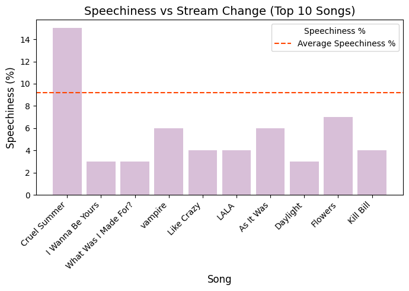

```python
# calculate the average speechiness
avg_speechiness = merged_dfs["speechiness_%"].mean()

# find top 10 songs by stream change again
top_10_songs = merged_dfs.nlargest(10, 'stream_change')

# get relevant columns-- song, stream_change, and speechiness_%
plot_data = top_10_songs[['song', 'stream_change', 'speechiness_%']]

# create a bar plot
fig, ax = plt.subplots(figsize=(7, 5))

# calculate positions for the bars to control their spacing
x = np.arange(len(plot_data))  # The position of each bar
bar_width = 0.85  # Make the bars narrower
ax.bar(x, plot_data['speechiness_%'], color='thistle', width=bar_width)

# adding a line showing the average speechiness_%
ax.axhline(avg_speechiness, color="orangered", linestyle="--", label="Average Speechiness %")

# adjust labels for song names
ax.set_xticks(x)
ax.set_xticklabels(plot_data['song'], rotation=45, ha='right')

# labeling
plt.title("Speechiness vs Stream Change (Top 10 Songs)", fontsize=14)
plt.ylabel("Speechiness (%)", fontsize=12)
plt.xlabel("Song", fontsize=12)
plt.legend(title="Speechiness %", fontsize=10)
plt.tight_layout()

plt.show()
```

Cruel Summer by Taylor Swift looks like it is skewing the data as it is significantly above the mean while the rest fall under. We assume that this song is skewing the mean speechiness of the top 10 songs so we calculate the mean not including this song. We see that the mean does go down and further away from the average speechiness of all the songs. This could suggest that there is a correlation between having a lower speechiness and performing better.

```python
# remove the song "Cruel Summer" from top 10 to see the data without it
top_10_wout_cs = top_10_songs[top_10_songs['song'] != 'Cruel Summer']

# find the average speechiness of the remaining songs
avg_speechiness_wout_cs = top_10_wout_cs['speechiness_%'].mean().round(2)

# average speechiness of the top 10 songs (with cruel summer)
avg_speechiness = top_10_songs['speechiness_%'].mean().round(2)

print("Average Speechiness of the top 10 songs:", avg_speechiness)
print("Average Speechiness of the top 10 songs excluding Cruel Summer:", avg_speechiness_wout_cs)
```

```
Average Speechiness of the top 10 songs: 5.5
Average Speechiness of the top 10 songs excluding Cruel Summer: 4.44
```

Next, we compare the danceability percentage for the top 10 songs with the largest stream_change and the average. There are no obvious outliers skewing the data. This means that there is not a big difference in the top 10 songs' danceability and could potentially show that songs perform best when near the top 10 songs' mean of 57% danceability. Note, this is not saying that songs perform better if they have similar danceability to these top 10 songs (not causation), but could hint at a correlation.

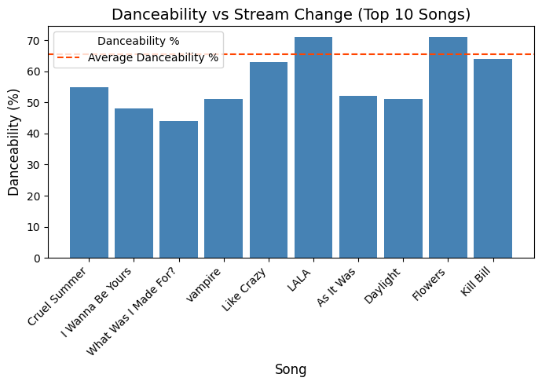

```python
# calculate the average danceability
avg_danceability = merged_dfs["danceability_%"].mean()

# extract columns we want
plot_data = top_10_songs[['song', 'stream_change', 'danceability_%']]

# make a bar plot
fig, ax = plt.subplots(figsize=(7, 5))

# calculate positions for the bars (to control their spacing)
x = np.arange(len(plot_data))
# make the bars narrower
bar_width = 0.85
ax.bar(x, plot_data['danceability_%'], color='steelblue', width=bar_width)

# add a line showing the average speechiness_%
ax.axhline(avg_danceability, color="orangered", linestyle="--", label="Average Danceability %")

# adjust x-tick labels for song names
ax.set_xticks(x)
ax.set_xticklabels(plot_data['song'], rotation=45, ha='right')

# label
plt.title("Danceability vs Stream Change (Top 10 Songs)", fontsize=14)
plt.ylabel("Danceability (%)", fontsize=12)
plt.xlabel("Song", fontsize=12)
plt.legend(title="Danceability %", fontsize=10)
plt.tight_layout()

plt.show()
```

We visualize the valence percentage for the top 10 songs versus the average valence for all the songs. What Was I Made For? by Billie Eilish may be considered an outlier but there are other songs with low valence. We will check anyway to see if it is significantly skewing the mean.

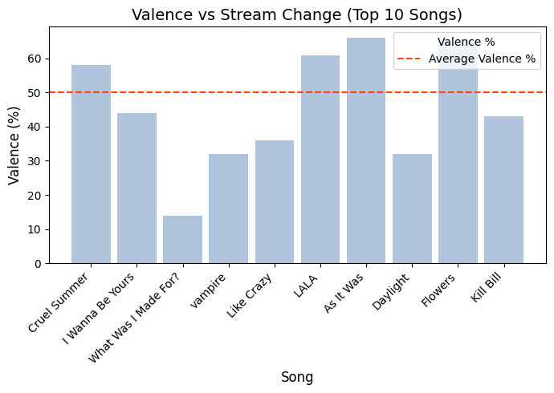

```python
# calculate average valence_%
avg_valence = merged_dfs["valence_%"].mean()

# get relevant columns
plot_data = top_10_songs[['song', 'stream_change', 'valence_%']]

# create a bar plot
fig, ax = plt.subplots(figsize=(7, 5))

# calculate positions for the bars to control their spacing
# position of each bar
x = np.arange(len(plot_data))
# make the bars narrower
bar_width = 0.85
ax.bar(x, plot_data['valence_%'], color='lightsteelblue', width=bar_width)

# add a line which shows speechiness_% mean
ax.axhline(avg_valence, color="orangered", linestyle="--", label="Average Valence %")

# adjust x-tick labels for song names
ax.set_xticks(x)
ax.set_xticklabels(plot_data['song'], rotation=45, ha='right')

# label
plt.title("Valence vs Stream Change (Top 10 Songs)", fontsize=14)
plt.ylabel("Valence (%)", fontsize=12)
plt.xlabel("Song", fontsize=12)
plt.legend(title="Valence %", fontsize=10)
plt.tight_layout()

plt.show()
```

Let's check if Billie Eilish's song could be considered an outlier. For a simple way to check, we use the inter quartile range (IQR) and see if the average valence_% for this song falls within the its upper and lower bounds. For more reading on this method, click [here](https://online.stat.psu.edu/stat200/lesson/3/3.2). From our calculations, we see that the bounds of the IQR are (-7.875, 101.125). With a valence_% of 14, the song What Was I Made For? falls within these bounds and is not considered an outlier. Thus, we can assume that a song does not have to be positive to perform well and that the average valence of the top 10 songs is not being skewed by this one song. In fact, 6 out of 10 of these songs fall below the valence of 50% line, meaning majority of these top 10 songs are not extremely positive and gearing towards negative.

```python
# calculate Q1 (25th percentile) and Q3 (75th percentile) for valence_% in top 10 songs
Q1 = top_10_songs['valence_%'].quantile(0.25)
Q3 = top_10_songs['valence_%'].quantile(0.75)

# calculate the IQR
IQR = Q3 - Q1

# calculate the lower and upper bounds
lower_bound = Q1 - 1.5 * IQR
upper_bound = Q3 + 1.5 * IQR
print("Upper Bound:", upper_bound)
print("Lower Bound:", lower_bound)

# get the valence_% for billie's song
billie = merged_dfs.loc[merged_dfs['song'] == 'What Was I Made For?', 'valence_%']
print("Valence_% for What Was I Made For?:" , billie.values[0])
```

```
Upper Bound: 101.125
Lower Bound: -7.875
Valence_% for What Was I Made For?: 14
```

# Linear Regression Models

We plan to use danceability, valence, and speechiness (independent variables) to predict the growth of a song's streams (stream_count, dependent variable). Thus, we will use a multiple linear regression model first to see if the independent variables will be good predictors of the dependent variable.

```python
from sklearn.model_selection import train_test_split
from sklearn.linear_model import LinearRegression
from sklearn.metrics import r2_score
from sklearn.preprocessing import StandardScaler

# define independent variables (X) and dependent variable (y)
X = merged_dfs[['danceability_%', 'valence_%', 'speechiness_%']]
y = merged_dfs['stream_change']

# initialize the scaler and standardize the independent variables
scaler = StandardScaler()
X_scaled = scaler.fit_transform(X)

# split the data into training and testing sets, using train_test_split
X_train, X_test, y_train, y_test = train_test_split(X_scaled, y, test_size=0.2, random_state=50)

# create the linear regression model
model = LinearRegression()
# fit the model
model.fit(X_train, y_train)

# make predictions on the test set
y_pred = model.predict(X_test)

# calculate mae
mae = (y_test - y_pred).abs().mean()
print("Mean Absolute Error:", mae)

# calculate r2
r2 = r2_score(y_test, y_pred)
print("R-squared:", r2)
```

```
Mean Absolute Error: 122371861.56929998
R-squared: 0.11288729882594617
```

From our model above, we see that we get a mean absolute error (MAE) of 122,371,861.57 (rounded). This shows that predictions made by your model are off by about 122 million units of the stream change ([additional reading on MAE](https://www.sciencedirect.com/topics/engineering/mean-absolute-error)). With the range of stream change between 12,307,680 and 1,387,406,000 streams, an MAE of 122,371,861.57 streams, we get a relative measure of error of 8.9% (MAE/range). This is not great and a MAE is high which suggests that the model's predictions are not very close to the actual values. The r-squared value says that the model explains only about 11.3% of the variance in the dependent variable (stream_change). See additional reading on r-squared values.). This means that the songs attributes explain only a small fraction of the variance in stream change, and thus there might be weak relationship between danceability, valence, speechiness, and stream_change.

Lets look at a simple linear regression model that only models one independent variable, danceability, on the dependent variable, stream change. This will tell us if one attribute at a time is a better predictor of a songs stream change.

```python
# define the independent variable (X) and dependent (y)
X = merged_dfs[['danceability_%']]
y = merged_dfs['stream_change']

# to standardize the data, initialize the scaler
scaler = StandardScaler()
X_scaled = scaler.fit_transform(X)

# Split the data into training and testing sets
X_train, X_test, y_train, y_test = train_test_split(X_scaled, y, test_size=0.2, random_state=50)

# Create and fit the linear regression model
model = LinearRegression()
model.fit(X_train, y_train)

# Make predictions on the test set
y_pred = model.predict(X_test)

# calculate mae
mae = (y_test - y_pred).abs().mean()
print("Mean Absolute Error:", mae)

# calculate r2
r2 = r2_score(y_test, y_pred)
print("R-squared:", r2)
```

```
Mean Absolute Error: 125760620.57149044
R-squared: 0.06236157331275116
```

As seen above, we get an even lower r-squared value and higher mean absolute error. Therefore, our multiple linear regression model is utilizing the additional independent variables to improve prediction accuracy.

We check if this is the same for a simple linear regression model for valence on stream change:

```python
# define the independent variable (valence), and dependent variable (stream_change)
X = merged_dfs[['valence_%']]
y = merged_dfs['stream_change']

# to standardize the data, initialize the scaler
scaler = StandardScaler()
X_scaled = scaler.fit_transform(X)

# split the data into training and testing sets, using train_test_split
X_train, X_test, y_train, y_test = train_test_split(X_scaled, y, test_size=0.2, random_state=50)

# create and fit the linear regression model
model = LinearRegression()
model.fit(X_train, y_train)

# make predictions on the test set
y_pred = model.predict(X_test)

# calculate mae
mae = (y_test - y_pred).abs().mean()
print("Mean Absolute Error:", mae)

# calculate r2
r2 = r2_score(y_test, y_pred)
print("R-squared:", r2)
```

```
Mean Absolute Error: 128660122.76117736
R-squared: 0.02920874624697034
```

As seen above, the MEA is higher and the r-squared value is lower compared to our multiple linear regression model. This means that valence is not a strong predictor of stream_change in a simple linear regression model. But, in general, the MAE is still high and the R-squared value is still low.

Lastly, we make a simple linear regression model for speechiness on stream change to see if just speechiness is a good predictor:

```python
# Define the independent variable, speechiness, and dependent variable, stream_change
X = merged_dfs[['speechiness_%']]
y = merged_dfs['stream_change']

# to standardize the data, initialize the scaler
scaler = StandardScaler()
X_scaled = scaler.fit_transform(X)

# split the data into training and testing sets, using train_test_split
X_train, X_test, y_train, y_test = train_test_split(X_scaled, y, test_size=0.2, random_state=50)

# create and fit the linear regression model
model = LinearRegression()
model.fit(X_train, y_train)

# make predictions on the test set
y_pred = model.predict(X_test)

# calculate mae
mae = (y_test - y_pred).abs().mean()
print("Mean Absolute Error:", mae)

# calculate r2
r2 = r2_score(y_test, y_pred)
print("R-squared:", r2)
```

```
Mean Absolute Error: 121280151.0173693
R-squared: 0.07046818852807646
```

Notably, the MAE is a little lower here than for our multiple linear regression model, meaning that speechiness alone is a little bit of of a better predictor of predicting average error. However, as seen above, we still get a high MAE and low r-squared value again for this simple linear regression model. Meaning, that speechiness alone is also not a good predictor for stream_change

Overall, with a high MAE indicating significant errors in prediction and a low R-squared showing that the model struggles to explain variability in the data, they suggest that our models our not good at predicting the stream_count variable (growth of a song's streams).

# **Conclusion**

In conclusion, there is some correlaton between speechiness, danceability, valence and stream change, but there is not enough of a correlation to accurately predict a song's growth over time. This is evident by multiple and singular linear regression models, which all had high MAEs and low r-squared values, meaning the models do not provide accurate predictions. Our analysis of the data through graphs, tables, and summary statistics supports these models, as we saw in our heatmap that the correlation between the independent variables and the dependent variable was not very strong. Moreover, we dove into what songs are popular on the platformand analyzed the worst performing songs over time versus the best performing ones. We saw that in some cases, the song's shared similar statistics which lead us to believe that there are other variables at work influencing a song's growth in stream counts.

It is understandable that these three attributes are not the best predictors because of all the outside factors that affect the popularity of a song. For instance, whether the artist is on tour, its goes viral on social media, and even the artists established popularity likely influence the popularity of a song and how much it is streamed.

**additional code for notebook conversion:**

```python
!ls "/content/drive/MyDrive/Colab Notebooks"
```

[output not shown]

```python
!mv "/content/drive/MyDrive/Colab Notebooks/Project" "/content/drive/MyDrive/Colab Notebooks/Project.ipynb"
```

[output not shown]

```python
%%shell
jupyter nbconvert --to html "/content/drive/MyDrive/Colab Notebooks/Project.ipynb"
```

[output not shown]